# Tarea 2 Modelos Lineales

## 5. ¿Qué relación observa entre las variables `UsuariosRegistrados` y `UsuariosCasuales` con respecto a la variable a predecir `TotalUsuarios`? Esto implica que las variables `UsuariosRegistrados` y `UsuariosCasuales` deben ser ignoradas en la construcción de la regresión ¿Por qué?

Su relación es fuerte con la variable a predecir podría indicar debido a su aporte en el modelo que son practicamente lo mismo que TotalUsuarios.

## 6. Ejecute nuevamente una Regresión Lineal, pero esta vez elimine (ignore) desde `R` las variables `UsuariosRegistrados` y `UsuariosCasuales` y usando el valor absoluto de los coeficientes β determine cuáles son las 3 variables que mayor importancia tienen en la regresión.

```r
modelo.lm <- lm(TotalUsuarios~., data = datos.aprendizaje[,-c(12,11)])
summary(modelo.lm)
```

```
Call:
lm(formula = TotalUsuarios ~ ., data = datos.aprendizaje[, -c(12,
    11)])

Residuals:
    Min      1Q  Median      3Q     Max
-357.69  -96.37  -30.90   52.71  711.40

Coefficients:
                  Estimate Std. Error t value Pr(>|t|)
(Intercept)        4.28900   10.93409   0.392  0.69487
Estacion           5.49240    1.30215   4.218 2.48e-05 ***
Hora               7.33323    0.19487  37.632  < 2e-16 ***
Feriado          -21.72526    7.89732  -2.751  0.00595 **
DiaSemana          1.61736    0.63970   2.528  0.01147 *
DiaTrabajo         1.51938    2.83452   0.536  0.59195
TipoClima         -2.47830    2.24708  -1.103  0.27009
SensacionTermica   1.08591    0.51081   2.126  0.03353 *
TemperaturaReal    2.45329    0.41708   5.882 4.15e-09 ***
Humedad           -2.05644    0.07978 -25.776  < 2e-16 ***
VelocidadViento    0.32802    0.16899   1.941  0.05227 .
---
Signif. codes:  0 '***' 0.001 '**' 0.01 '*' 0.05 '.' 0.1 ' ' 1

Residual standard error: 150 on 13893 degrees of freedom
Multiple R-squared:  0.3286,    Adjusted R-squared:  0.3281
F-statistic: 679.8 on 10 and 13893 DF,  p-value: < 2.2e-16
```

```r
coef(modelo.lm)
```

```
     (Intercept)         Estacion             Hora          Feriado
       4.2889999        5.4924023        7.3332338      -21.7252623
       DiaSemana       DiaTrabajo        TipoClima SensacionTermica
       1.6173555        1.5193803       -2.4783035        1.0859097
 TemperaturaReal          Humedad  VelocidadViento
       2.4532899       -2.0564405        0.3280155
```

## 7. Para la Regresión Lineal del item 6 interprete la Raíz Error Cuadrático Medio y el Error Relativo.

```r
# Hace la Predicción
prediccion <- predict(modelo.lm, datos.prueba)
# Medición de precisión
pre.lm <- indices.precision(datos.prueba$TotalUsuarios, prediccion,numero.predictoras)
pre.lm
```

```
$error.cuadratico
[1] 20635.69

$raiz.error.cuadratico
[1] 143.9207

$error.relativo
[1] 0.56703

$correlacion
[1] 0.5712893
```

Además en promedio el modelo se equivocó un 56% del valor real.

## 9. Corra un modelo de regresión Penalizada tipo Lasso. ¿Por qué se puede decir que prácticamente el resultado es el mismo que el de la Regresión Lineal? Justifique usando el gráfico **Coeficientes** y **lambda** y con base en los **Coeficientes** β.

```r
library(glmnet)

y <- datos$TotalUsuarios
x<-model.matrix(TotalUsuarios~.,datos)[,-1]
lasso.mod <- glmnet(x,y,alpha =1)
```

### Coeficientes lambda

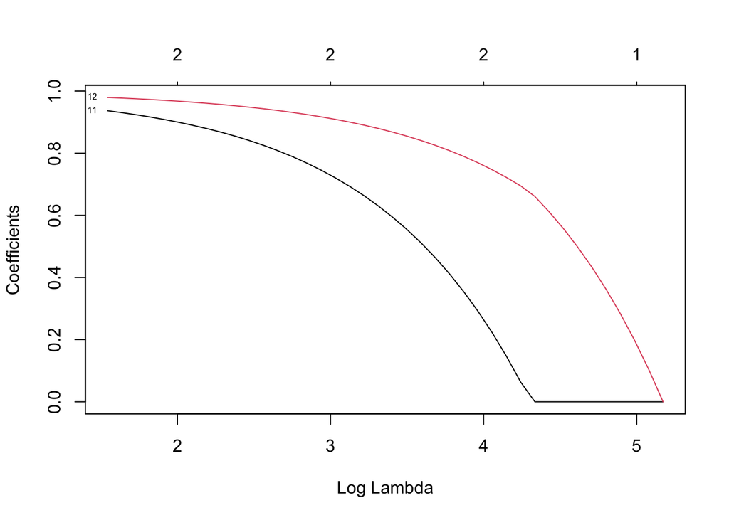

```r
plot(lasso.mod,"lambda", label=TRUE)
```

### Beta

```r
coef(lasso.mod)[,5]
```

```
        (Intercept)            Estacion                Hora             Feriado
        133.7890661           0.0000000           0.0000000           0.0000000
          DiaSemana          DiaTrabajo           TipoClima    SensacionTermica
          0.0000000           0.0000000           0.0000000           0.0000000
    TemperaturaReal             Humedad     VelocidadViento    UsuariosCasuales
          0.0000000           0.0000000           0.0000000           0.0000000
UsuariosRegistrados
          0.3620206
```

```r
x<- model.matrix(TotalUsuarios~.,datos)[,-1]
y<-datos$TotalUsuarios

options(max.print = 2000,width=2000)


# Usando validación cruzada para determinar el mejor Lambda
sal.cv<-cv.glmnet(x,y,alpha=0)

# Construye el Modelo LASSO
lasso.mod<-glmnet(x,y,alpha=1)


x.datos.prueba<-model.matrix(TotalUsuarios~.,datos.prueba)[,-1]

mejor.lambda<-sal.cv$lambda.min
mejor.lambda
```

```
[1] 17.6331
```

```r
coef(lasso.mod)[,which(lasso.mod$lambda==mejor.lambda)]
```

```
13 x 0 sparse Matrix of class "dgCMatrix"

(Intercept)
Estacion
Hora
Feriado
DiaSemana
DiaTrabajo
TipoClima
SensacionTermica
TemperaturaReal
Humedad
VelocidadViento
UsuariosCasuales
UsuariosRegistrados
```

```r
pred1<-predict(lasso.mod,newx=x.datos.prueba,type = "coefficients")

pred<-predict(lasso.mod,newx=x.datos.prueba)

numero.predictoras <- dim(datos)[2] - 1

numero.filas <- dim(datos)[1]


indices.calidad <- indices.precision(datos.prueba$TotalUsuarios,pred,numero.predictoras)
indices.calidad
```

```
$error.cuadratico
[1] 196250.6

$raiz.error.cuadratico
[1] 443.8328

$error.relativo
[1] 8.659484

$correlacion
 [1]        NA 0.9712601 0.9712601 0.9712601 0.9712601 0.9712601 0.9712601 0.9712601 0.9712601 0.9712601 0.9770675 0.9830793 0.9873252 0.9903831 0.9926233 0.9942887 0.9955427 0.9964971 0.9972275 0.9977965 0.9982406 0.9985895 0.9988652 0.9990840 0.9992586 0.9993984 0.9995108 0.9996013 0.9996745 0.999…
```

```r
pred1
```

[output not shown]

Yo creería que al no elegir el lambda manualmente este utiliza uno por default y de esta forma vuelve a utilizar las variables `UsuariosCasuales` y `UsuariosRegistrados` para el modelo.